# Data management and transfer

Week 11 – Lecture B

Author

Affiliations

Jelmer Poelstra

[CFAES Bioinformatics Core, Ohio State University](https://go.osu.edu/bioinformatics-core)

[Dept. of Plant Pathology, Ohio State University](https://plantpath.osu.edu)

Presented on

November 4, 2026

Page last modified

October 25, 2026

## 1 Introduction

### 1.1 Learning goals

- Why you should prefer relative paths over absolute paths
- How you can manage your data and share it after publication
- How to organize sample metadata in spreadsheets
- How to transfer files between OSC and other computers like your own
- How to download files at the command line
- How to compress and decompress files

### 1.2 Getting ready

1. At https://ondemand.osc.edu, start a VS Code session in `/fs/ess/PAS3493/people/$USER`
2. Make sure you have installed FileZilla on your computer (instructions).

## 2 Relative and absolute paths

### 2.1 Why you should prefer relative paths

**Absolute paths don’t depend on your working dir – so what could be a disadvantage of using them?**

*The answer will be added after class.*

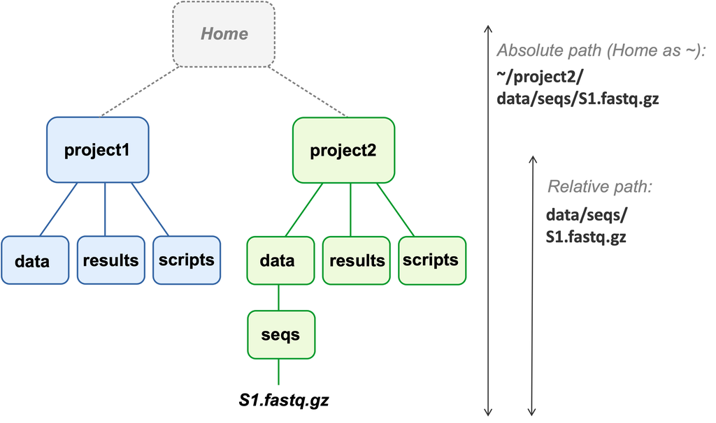

Two project dir hierarchies, and the absolute and relative paths to a FASTQ file (FASTQ files contain HTS reads).  
Following best practices, the relative path starts from the relevant project’s top-level dir.  
(Note that `~` is a way to refer to your Home folder.)

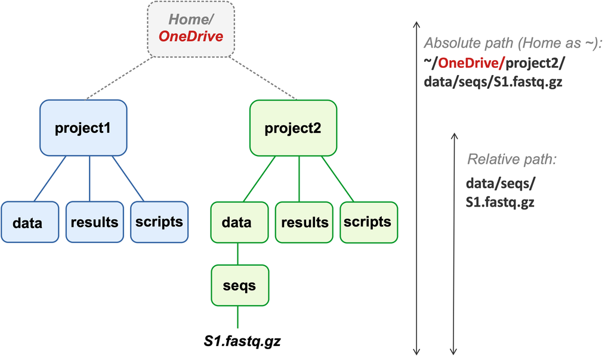

Now, both projects were moved into `OneDrive`.  
The absolute path to the FASTQ file has changed,  
but the relative path from the project’s top-level dir remains the same.

**Tip**

Relative paths keep working after moving project dirs – **as long as you consistently use the project’s top-level dir as your working dir**.

**On Monday, you referred to input files from `week11` with relative paths like `../garrigos/fastq/S63_R1.fastq.gz`. Would these still work after moving `week11` into a new dir? And after moving your entire personal dir?**

*The answer will be added after class.*

## 3 Raw data management

In general, any type of raw data from your research is extremely valuable. These are the results of your experiment, and they may have been labor-intensive and expensive to produce.

In the examples in this course, raw data has been in the form of FASTQ files. More generally with (epi)genomics and transcriptomics projects, your main piece of raw data will be a set of sequence files, most commonly in FASTQ format. However, similar principles apply with other types of data/files.

### 3.1 Key recommendations

- **Never delete your raw data.** It doesn’t matter if you “finished” your downstream analyses, or produced processed FASTQ files that you personally find more useful: your ground truth will always be the raw data. These ensure that your results can be reproduced by yourself and others, and they allow for a modified re-analysis of the data after e.g. new methods or relevant data become available.
- **Keep multiple copies of your raw data.** You should always keep two or more copies of your raw data, ideally in at least two different physical locations. So, even if your data mainly lives on OSC, also keep a copy elsewhere. And on OSC, you should never only store files in a scratch dir, since files that haven’t been used for a while are automatically deleted there.
- **Share your raw data publicly after publication.** Most journals and funding agencies nowadays require that research data is made publicly available after publication of the results. While this is somewhat of a novelty for some types of data, sequencing data has long been expected to be shared publicly.
- Also:
  - Keep track of data provenance and metadata
    - When and from where was the data obtained/received?
    - What metadata exists for each sample?
  - Use standard and preferably plain-text file formats
  - To avoid accidents, consider making your data read-only with file permissions *(bonus material)*
  - After downloading or when sharing key data, consider using “checksums” to check that files were transferred entirely *(bonus material)*

### 3.2 Metadata in spreadsheets

Sample metadata, such as which treatment and time point each sample belongs to, is often entered in a spreadsheet program like Excel. That is fine, as long as you organize the spreadsheet so that it can be read by code without manual cleanup. The Turing Way’s [Data Organisation in Spreadsheets](https://book.the-turing-way.org/reproducible-research/rdm/rdm-spreadsheets) page has detailed recommendations, including:

- Use one row per sample (or observation) and one column per variable, with a single header row at the top.
- Put only one value in each cell.
- Don’t use merged cells, colors, or other formatting to store information: if you want to highlight some cells, add a column for this instead.
- Use consistent sample names, category labels, and units throughout.
- Avoid spaces and special characters in sample names and column names (e.g. use `time_point` rather than `Time point (days)`).
- Write dates as `YYYY-MM-DD` (e.g. `2026-11-04`), which is unambiguous and sorts correctly.
- Choose a single way to indicate missing data (e.g. `NA`), rather than leaving some cells empty.
- Don’t do calculations or analyses in the spreadsheet that holds your raw metadata.
- Save (export) the final version as a plain-text CSV or TSV file, which is what you’ll read into your analysis code.

For an example, take a look at the `garrigos/meta/metadata.tsv` file you’ve seen before, with one row per sample and one column each for the sample ID, time point, and treatment.

**WarningExcel turns some gene names into dates**

Excel automatically converts text that *looks like* a date or number. For example, the gene names *SEPT2* and *MARCH1* become `2-Sep` and `1-Mar`. This is so common that around 20% of published papers with gene lists in Excel files [contained such errors](https://doi.org/10.1186/s13059-016-1044-7), and several human genes were renamed to avoid the problem (e.g. *SEPT2* is now *SEPTIN2*). To prevent this, set such columns to the “Text” format before entering or pasting data.

In week 13, you’ll see that this kind of layout is called “tidy data”, and that R works with it very well.

### 3.3 Details about sharing data and other files

This policy is now in effect:

> By the end of 2025, all federally-funded research must make articles and data publicly available immediately upon journal publication with no waiting periods allowed.

> — [Federal Research Policy Guide](https://research.osu.edu/federal-research-policy-guide-public-access-requirements) from OSU’s [Enterprise for Research, Innovation and Knowledge](https://erik.osu.edu/)

#### Platforms for sharing data

- Raw sequences from high-throughput sequencing, such as FASTQ files, are usually uploaded to NCBI’s [Sequence Read Archive (SRA)](https://www.ncbi.nlm.nih.gov/sra) (or its European counterpart, [ENA](https://www.ebi.ac.uk/ena/browser/home)).
- Some results should also be uploaded to NCBI, such as genome assemblies and annotations, and gene expression count tables (Gene Expression Omnibus, [GEO](https://www.ncbi.nlm.nih.gov/geo/)). For RNA-seq data, a GEO submission also takes care of uploading the reads to the SRA.
- Other results and data can be shared via general data repositories like [Dryad](https://datadryad.org/) and [Zenodo](https://zenodo.org/), which journals increasingly require upon publication.
- Code can be shared via GitHub (or similar platforms like GitLab and Bitbucket), ideally with a permanent Digital Object Identifier (DOI) via [Zenodo’s GitHub integration](https://docs.github.com/en/repositories/archiving-a-github-repository/referencing-and-citing-content)[^1].

**TipGetting a DOI for your GitHub repository with Zenodo *(Click to expand)**

A GitHub repository can be changed or deleted at any time, which makes it a poor permanent reference in a paper. Zenodo, a general data repository run by CERN, can archive a snapshot of your repo and give it a citable DOI:

1. Log in to [Zenodo](https://zenodo.org/) with your GitHub account.
2. In Zenodo, go to your account’s GitHub settings, and flip the switch next to the repository you want to archive (the repository needs to be public).
3. On GitHub, create a “release” of your repository (on the repository’s front page, click “Create a new release” in the right sidebar).

Zenodo will then automatically archive this release and assign it a DOI, which you can cite in your paper and add as a badge to your README. Each new release gets its own DOI, plus there is a “concept DOI” that always points to the latest version.

See [GitHub’s documentation](https://docs.github.com/en/repositories/archiving-a-github-repository/referencing-and-citing-content) for more details.

**NoteData Management Plans *(Click to expand)**

Data Management Plans (DMPs), which specify how you are planning to manage and share your data, are also required by major funding agencies (e.g., NSF has required them since 2011):

> A DMP is currently required for all competitive grant programs of the United States Department of Agriculture and the National Science Foundation.

> — Grünwald et al. (2024)

Here are specific guidelines for [USDA NIFA](https://www.nifa.usda.gov/grants/lifecycle/pre-award/data-management-plans) and [NSF](https://www.nsf.gov/funding/data-management-plan) grants.

For more and OSU-specific information about data management and sharing, [OSU’s Research Commons](https://library.osu.edu/researchcommons) has [guides](https://guides.osu.edu/rdm-best-practice/how-to-share) and [offers consultations](https://library.osu.edu/research-data).

## 4 File transfer to and from OSC

### 4.1 Should I keep my OSC and local directories synced, and how?

You can’t keep files synced between OSC and your local computer in a fully automatic way like with OneDrive or Dropbox. And because the amount of data on OSC is typically very large, you may not want to either. Instead, here is a good strategy:

- Keep the files you have under version control (code, etc.) synced via Git/GitHub.
- Periodically sync all or a selection of other files with the data transfer methods discussed below.

Data syncing is especially important when you do analyses both at OSC and on your local computer for a given project. To reduce this friction, I recommend that for projects for which you need OSC, you instead try to do *all* your work there. When you do that, it even works to keep entirely separate sets of files at OSC and your local computer – for example, you may keep only the manuscript and related files on your local computer (and/or OneDrive/Teams), and everything else at OSC.

### 4.2 Overview of transfer options

In week 2, you learned that you can upload and download files from OSC in the OnDemand Files menu. However, that method is only suitable for relatively small transfers. Here is a table with methods to transfer files between your computer and OSC:

| Method | Transfer size | CLI or GUI | Ease of use | Flexibility/options |
| --- | --- | --- | --- | --- |
| **OnDemand Files menu** | smaller (<1GB) | GUI | Easy | Limited |
| **Remote transfer commands** (e.g. `scp`, `rsync`) | any | CLI | Moderate | Extensive |
| **SFTP** | any | Either | Moderate | Extensive |
| **Globus** | larger (>1GB) | GUI | Moderate | Extensive |

### 4.3 FileZilla: a GUI-based SFTP client

Here, we’ll go over what is probably overall the most convenient and versatile way to transfer files to and from OSC, since it works for transfers of any size, and is easy and quick: **file transfer with a GUI-based SFTP client**. There are several such programs, but I can recommend FileZilla[^2]. Let’s give that a try!

1. **Install FileZilla**
   - For OSU-managed computers:  
     Open the “Software Center” (Windows) or “Ohio State Application Self Service” (Mac), search for “FileZilla”, and click the install button.
   - For personal computers:  
     Go to the [FileZilla download page](https://filezilla-project.org/download.php?type=client) — it should automatically display a big green download button for your operating system: click on that, then install the program, and open it. On Windows, the installer may offer to install additional software: decline these offers.
2. **Connect to OSC**  
   Open FileZilla. To connect it to OSC, find the **Site Manager**: click `File` in the top menu bar and then `Site Manager`[^3]. In the Site Manager, enter/select the following:
   - *Protocol*: “SFTP - SSH File Transfer Protocol”
   - *Host*: `sftp.osc.edu` (leave the Port box empty)
   - *Logon Type*: Make sure “Normal” is selected
   - *User*: Type your OSC username
   - *Password*: Enter your OSC password
   - Click the “**Connect**” button at the bottom to connect to OSC

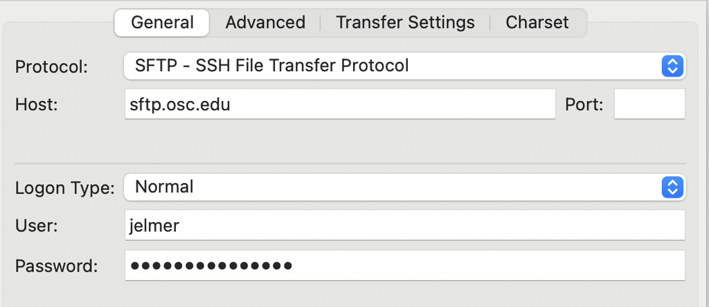

3. **The connection interface**  
   Once connected, your main screen is split with a local file explorer on the left, and a remote file explorer on the right:

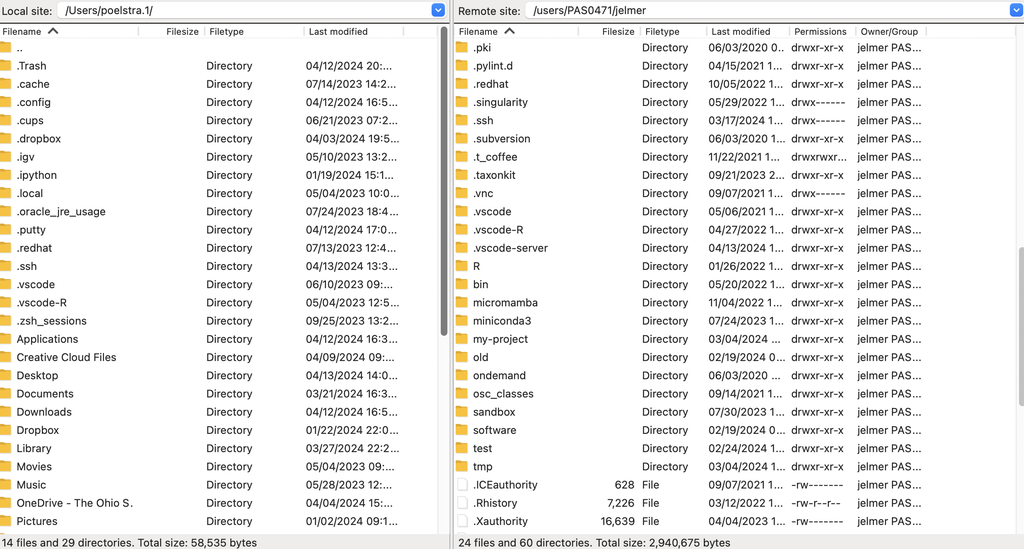

4. **Changing directories**  
   You can change directories in either file explorer. At OSC, your default location is your Home dir within `/users/`, but you can type a path in the top bar to e.g. go to `/fs/ess/PAS3493` – and from there you can further click your way to your personal dir there.

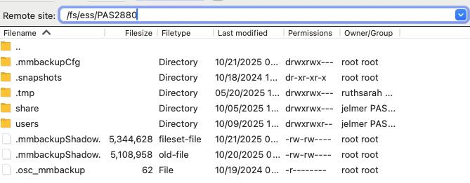

5. **Transferring files**  
   Transferring dirs and files in either direction is as simple as dragging and dropping them to the other side!

#### Exercise: File transfer with FileZilla

In FileZilla, go to `/fs/ess/PAS3493/people/<your-username>` (`$USER` doesn’t work here, since FileZilla is not a shell). Then:

1. Download the MultiQC report from Monday’s nf-core run (`week11/results/nfc-rnaseq/multiqc/star_salmon/multiqc_report.html`) to your computer, and open it in your browser. (If your run hasn’t finished, pick any other HTML file, like a FastQC report from week 6.)
2. Upload any small file from your computer to the same dir at OSC, and check that it’s there with `ls` in your VS Code terminal.

## 5 Downloading files at the command line

When you need to get large files from public repositories like NCBI (e.g. reference genome files, raw reads from the SRA), I recommend **downloading them directly to OSC using commands** (instead of downloading to your own computer and then transferring to OSC). Not only is this quicker once you know how to, it is also much more reproducible: in your Markdown documentation files, you can store the exact commands used to obtain the data.

### 5.1 `wget`

You can download files from a URL using the `wget` command. It has *many* options, but basic usage is quite simple:

```bash
# This will download the file at the URL to your current working dir
wget <URL>
```

On Monday, you used `wget` to download the reference genome FASTA file for *Culex pipiens*, the focal species of the Garrigós et al. (2025) RNA-seq dataset we’ve been working with. Where did that URL come from? The files for that genome can be found at this [NCBI FTP webpage](https://ftp.ncbi.nlm.nih.gov/genomes/all/GCF/016/801/865/GCF_016801865.2_TS_CPP_V2/):

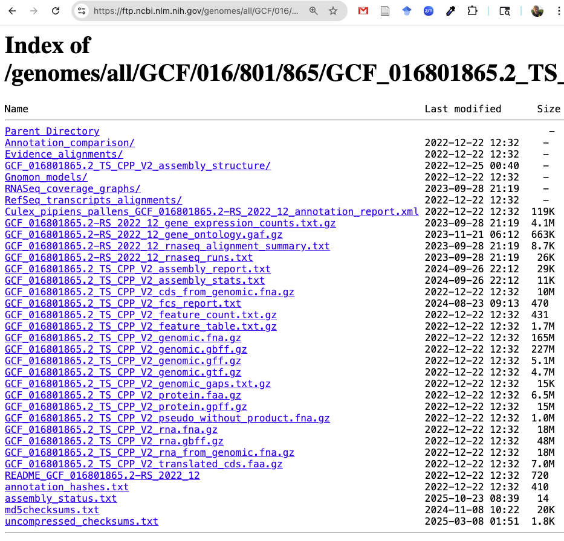

You can right-click on any of the files there and then click “Copy Link Address” (or similar, depending on your browser). That’s how I got the URL to the assembly FASTA (`.fna.gz`) file that we used on Monday. Here is the command again, but with paths relative to your personal dir (on Monday, you ran it from `week11`, hence the `../garrigos/ref` there):

```bash
# You already downloaded this file on Monday
URL=https://ftp.ncbi.nlm.nih.gov/genomes/all/GCF/016/801/865/GCF_016801865.2_TS_CPP_V2/GCF_016801865.2_TS_CPP_V2_genomic.fna.gz
wget -P garrigos/ref "$URL"
```

```
--2026-10-23 10:19:04--  https://ftp.ncbi.nlm.nih.gov/genomes/all/GCF/016/801/865/GCF_016801865.2_TS_CPP_V2/GCF_016801865.2_TS_CPP_V2_genomic.fna.gz
Resolving ftp.ncbi.nlm.nih.gov (ftp.ncbi.nlm.nih.gov)... 130.14.250.13, 130.14.250.10, 130.14.250.7, ...
Connecting to ftp.ncbi.nlm.nih.gov (ftp.ncbi.nlm.nih.gov)|130.14.250.13|:443... connected.
HTTP request sent, awaiting response... 200 OK
Length: 172904433 (165M) [application/x-gzip]
Saving to: ‘garrigos/ref/GCF_016801865.2_TS_CPP_V2_genomic.fna.gz’

GCF_016801865.2_TS_CPP_V2_genomic.fna.gz           100%[===============================================================================================================>] 164.89M  28.5MB/s    in 7.2s

2026-10-23 10:19:12 (23.0 MB/s) - ‘garrigos/ref/GCF_016801865.2_TS_CPP_V2_genomic.fna.gz’ saved [172904433/172904433]
```

- `wget` downloads files to your working dir by default, but we used its `-P` option to directly download into the `garrigos/ref` dir.
- As you can see, `wget` is quite chatty and prints a bunch of logging and progress info to the screen.

Right after downloading, the file looked like this (on Monday, you then unzipped it):

```bash
ls -lh garrigos/ref/*fna.gz
```

```
-rw-rw----+ 1 jelmer PAS0471 165M Dec 22  2022 garrigos/ref/GCF_016801865.2_TS_CPP_V2_genomic.fna.gz
```

Note that the date shown, `Dec 22 2022`, is when NCBI last modified the file, not when you downloaded it.

Because you pasted the download command into your `week11/README.md` on Monday, anyone (including future you) can see exactly where this file came from, and download it again.

#### Exercise: Download the protein sequences

On the same NCBI page, there is a FASTA file with the sequences of all predicted proteins (`GCF_016801865.2_TS_CPP_V2_protein.faa.gz`).

1. Download it into `garrigos/ref` with a single command.
2. How many proteins are in the file? (Hint: each sequence has a header line starting with `>`, and you don’t need to unzip the file first.)

**NoteAnother download command: `curl`**

Another commonly used downloading command is `curl` – both have similar functionality, so you don’t really need to learn both. But you may see examples with `curl` elsewhere.

**TipTips for other kinds of genomics downloads**

- For reference genome downloads, NCBI also has a relatively new portal called **“datasets”** [that also includes a CLI tool with the same name](https://www.ncbi.nlm.nih.gov/datasets/docs/v2/reference-docs/command-line/datasets). This tool is very useful if you want to download multiple or many genomes – for example, it allows you to download all available genomes of say a certain genus with a single command.
- For downloads from the Sequence Read Archive (SRA), which contains high-throughput sequencing reads, you can use tools like fasterq-dump and fastq-dl. Also handy is the simple [SRA explorer website](https://sra-explorer.info), where you can enter an NCBI accession number and it will give you download links.

**TipHow to find a reference genome and its files for any species *(Click to expand)**

1. Go to the genome part of NCBI’s datasets portal https://www.ncbi.nlm.nih.gov/datasets/genome/.
2. Type in the name of a species (or other taxonomic level).

[figure not shown]

3. Select an appropriate taxonomic match within the search box, and press Enter. You will get a list of available genomes:

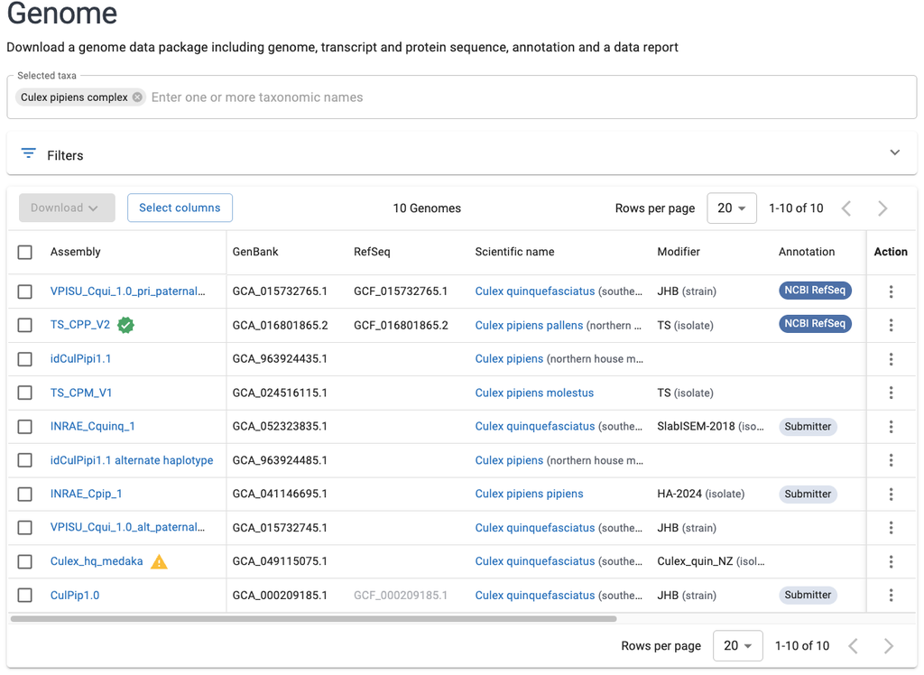

4. All else being equal (e.g. if it’s the right subspecies), it is generally a good idea to pick the “Reference” genome which is highlighted with a green checkmark, i.e. `TS_CPP_V2` in the screenshot above. Click on the name of the desired genome, and you will see a page like this:

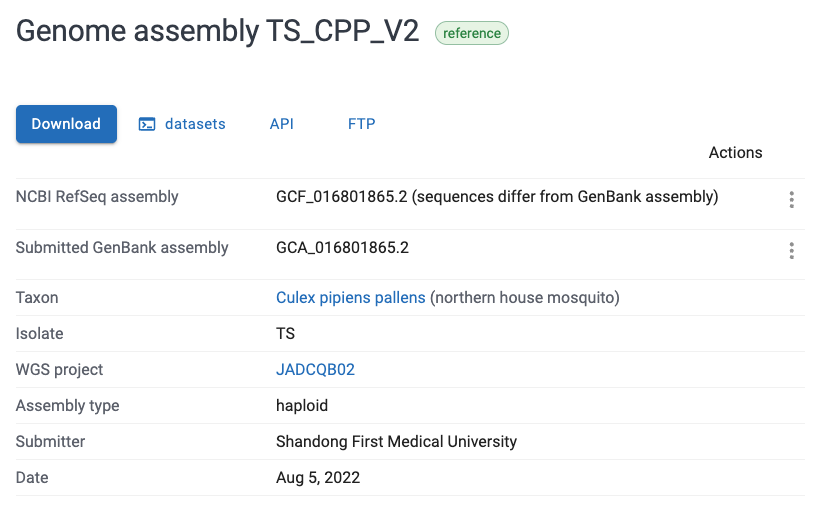

5. There are multiple ways of downloading, but the FTP page we downloaded from can be accessed by clicking the “FTP” button shown in the screenshot above.

## 6 File compression

Large data files, like the genome FASTA file you downloaded on Monday, are usually distributed in compressed form to save storage space and download time. In genomics, the most common compression format is **gzip**, recognizable by the `.gz` extension.

Many bioinformatics programs can read gzipped files directly — for example, you’ve never had to decompress your FASTQ files — and to view gzipped files, you’ve been using `zcat` instead of `cat` since week 4. But sometimes, you do need to decompress (“unzip”) a file, like you did on Monday with the reference genome files.

To practice, download a FASTA file with human chromosome 22 into your `sandbox` dir:

```bash
wget -P sandbox https://hgdownload.soe.ucsc.edu/goldenPath/hg19/chromosomes/chr22.fa.gz
```

### 6.1 Decompressing files with `gunzip`

To decompress a gzipped file, use the `gunzip` command:

```bash
gunzip sandbox/chr22.fa.gz
ls -lh sandbox/chr22*
```

```
-rw-rw----+ 1 jelmer PAS0471 50M Mar 20  2009 sandbox/chr22.fa
```

- `gunzip` decompresses files **in place**: the gzipped file is replaced by a decompressed file with the same name minus the `.gz`.
- You can decompress multiple files at once, e.g. with a wildcard, like you did on Monday with `gunzip -v ../garrigos/ref/*.gz` (the `-v` (verbose) option makes `gunzip` report on each file).

### 6.2 Compressing files with `gzip`

Conversely, to compress a file, use `gzip`, which also works in place:

```bash
gzip sandbox/chr22.fa
ls -lh sandbox/chr22*
```

```
-rw-rw----+ 1 jelmer PAS0471 11M Mar 20  2009 sandbox/chr22.fa.gz
```

The compressed file is about 5 times smaller than the decompressed one. So, only decompress files when needed, and consider compressing large plain-text files that you don’t use often.

**TipKeeping the original file *(Click to expand)**

Because `gzip` and `gunzip` replace the input file, you only have one version of the file afterwards. To keep the original, use the `-k` (keep) option:

```bash
gunzip -k sandbox/chr22.fa.gz
ls sandbox/chr22*
```

```
sandbox/chr22.fa  sandbox/chr22.fa.gz
```

You may also see the following method, which additionally lets you choose the name of the output file: the `-c` option makes `gzip`/`gunzip` print the output to standard out, which you can then redirect to a file:

```bash
gzip -c sandbox/chr22.fa > sandbox/chr22_copy.fa.gz
```

For more about compression, including searching gzipped files with `zgrep` and packing up entire dirs with `tar`, see the bonus material.

## 7 Recap

In this lecture, you have learned about best practices for managing and sharing your data, including why to prefer relative paths and how to organize metadata in spreadsheets, and the following practical applications:

- File transfer to and from OSC with FileZilla (and what other options exist)
- Downloading files at the command line with `wget`
- Compressing and decompressing files with `gzip` and `gunzip`

Back to top

## References

Garrigós, Marta, Guillem Ylla, Josué Martínez-de la Puente, Jordi Figuerola, and María José Ruiz-López. 2025. “Two Avian *Plasmodium* Species Trigger Different Transcriptional Responses on Their Vector *Culex pipiens*.” *Molecular Ecology* 34 (15): e17240. https://doi.org/10.1111/mec.17240.

Grünwald, Niklaus J., Clive H. Bock, Jeff H. Chang, et al. 2024. “Open Access and Reproducibility in Plant Pathology Research: Guidelines and Best Practices.” *Phytopathology®* 114 (5): 910–16. https://doi.org/10.1094/PHYTO-12-23-0483-IA.

## Footnotes

[^1]: Some journals require code to be shared via a general repository like Dryad as well, where the code (and especially its documentation) may be subject to manual quality control.
[^2]: E.g. because it works on all operating systems and has a more intuitive user interface than Cyberduck, another very commonly used program that works both on Mac and Windows.
[^3]: There is also an icon in the far top-left to access this menu. Additionally, there is a “Quickconnect” bar, but I’ve not managed to connect to OSC with that.